# Airbnb Data Science Project

Luke O’Connell and Yvonne Quach

May 14, 2025

# 1 Introduction

This project applies machine learning techniques to Airbnb listings in Los Angeles County to address three core business objectives, in the hopes of providing hosts data-driven information on how best to market, price, and respond to guest demand:

1. **Price Optimization** – Determine optimal nightly prices for listings based on factors such as room type, location, amenities, and review scores.
2. **Revenue Forecasting** – Predict revenue using booking history of similar rentals, allowing hosts to anticipate seasonal demand.
3. **Market Segmentation** – Cluster listings into distinct market segments to inform business strategies, marketing efforts, and pricing tiers.

The insights aim to support both hosts and platforms in making more data-informed decisions that enhance profitability and customer satisfaction.

## 1.1 Dataset Overview

## 1.2 Libraries and Setup

```r
getwd()
```

```
## [1] "/Users/leo/Desktop"
```

```r
# Load required libraries
library(dplyr)
library(tidyr)
library(tidyverse)
library(randomForest)
library(caret)
library(stringr)
library(forcats)
library(rsample)
library(glmnet)
library(glmnetUtils)
library(tidyverse)
library(cluster)
library(factoextra)
library(stringr)
library(ggfortify)

# Load the dataset, found here:

LA_listings <- read_csv("/Users/leo/Desktop/BUS659/project/LA_listings.csv",
    show_col_types = FALSE)

# https://insideairbnb.com/get-the-data/ -> 'Los Angeles, California,
# United States' header -> file name: 'listings.csv.gz'. Based on
# March 1, 2025 listings.
```

# 2 Price Optimization

Start: Price optimization… Predict optimal nightly rates based on listing’s characteristics, like room type, amenities, reviews, and location.

Since there are 3 objectives, all of which will require testing, training, and likely creation of similiar data sets, all data groups created for price optimization will begin with “opt_”.

## 2.1 Data Preparation

```r
#Select relevant columns and clean them for modeling
opt_LA_price <- LA_listings %>%
  select(price, room_type, neighbourhood_cleansed, number_of_reviews, review_scores_rating, minimum_nights, availability_365, latitude, longitude, amenities, bedrooms, bathrooms, beds) %>%
  mutate(

    # Convert price string to numeric
    price = as.numeric(gsub("[$,]", "", price)),

    # Convert categorical variables to factors
    room_type = as.factor(room_type),
    neighbourhood_cleansed = as.factor(neighbourhood_cleansed),

    #Convert bedroom/bathroom/bed counts to numeric
    bedrooms = as.numeric(bedrooms),
    bathrooms = as.numeric(bathrooms),
    beds = as.numeric(beds),

    # Create a new numeric feature: count of amenities
    amenities_count = str_count(amenities, ",") +1,

    #Price per bedroom (if bedroom is not 0), indicates price based on listing size
    price_per_bedroom = ifelse(bedrooms > 0, price / bedrooms, NA),

     #Price per bed, indicates price based on listing size
    price_per_bed = ifelse(beds > 0, price / beds, NA),

    #Indicator if listing is entire home, for price segmentation
    is_entire_home = ifelse(room_type == "Entire home/apt", 1, 0),

    #Log-transformed price to address skewness for sensitive distributions
    log_price = log1p(price)
  ) %>%

  # Drop any rows that have missing values in the selected columns
  drop_na() %>%

  # Drop the raw amenities text column
  select(-amenities)

# Random Forest cannot handle factors with more than 53 levels, so we group smaller neighborhoods into an "Other" category
opt_top_neighborhoods <- opt_LA_price %>%
  count(neighbourhood_cleansed, sort = TRUE) %>%
  slice(1:10) %>%
  pull(neighbourhood_cleansed) %>%
  as.character()

opt_LA_price <- opt_LA_price %>%
  mutate(neighbourhood_cleansed = fct_other(neighbourhood_cleansed, keep = opt_top_neighborhoods))
```

```r
# Linear Regression to determine which variables are statistically
# significant

library(tidymodels)
set.seed(123)
opt_split <- initial_split(opt_LA_price, prop = 0.8)
train_data <- training(opt_split)
test_data <- testing(opt_split)

lm_model <- lm(price ~ room_type + neighbourhood_cleansed + number_of_reviews +
    review_scores_rating + minimum_nights + availability_365 + latitude +
    longitude + bedrooms + bathrooms + beds + amenities_count + price_per_bed +
    is_entire_home, data = train_data)

summary(lm_model)
```

```
##
## Call:
## lm(formula = price ~ room_type + neighbourhood_cleansed + number_of_reviews +
##     review_scores_rating + minimum_nights + availability_365 +
##     latitude + longitude + bedrooms + bathrooms + beds + amenities_count +
##     price_per_bed + is_entire_home, data = train_data)
##
## Residuals:
##     Min      1Q  Median      3Q     Max
## -2976.2   -64.0     1.1    50.4 11611.3
##
## Coefficients: (1 not defined because of singularities)
##                                           Estimate    Std. Error
## (Intercept)                          -22199.186955   1458.563682
## room_typeHotel room                      37.171815     34.493949
## room_typePrivate room                    -7.210831      5.226354
## room_typeShared room                   -165.160142     28.986968
## neighbourhood_cleansedBeverly Hills     110.497479     18.978093
## neighbourhood_cleansedDowntown          -49.593177     19.549760
## neighbourhood_cleansedGlendale            2.768188     19.676928
## neighbourhood_cleansedHollywood         -47.335433     17.942441
## neighbourhood_cleansedLong Beach        -15.373069     16.600407
## neighbourhood_cleansedPasadena           26.412320     19.789432
## neighbourhood_cleansedSanta Monica      -37.740526     18.097173
## neighbourhood_cleansedVenice            -13.144401     17.840719
## neighbourhood_cleansedWest Hollywood    -29.157599     18.221615
## neighbourhood_cleansedOther             -11.871802     13.775950
## number_of_reviews                        -0.031813      0.020870
## review_scores_rating                     12.887221      4.984144
## minimum_nights                           -0.327298      0.095787
## availability_365                          0.027423      0.017428
## latitude                                -96.359657     13.472919
## longitude                              -213.147215     11.821508
## bedrooms                                 50.050038      3.334570
## bathrooms                               136.508612      2.801895
## beds                                      9.229064      1.924280
## amenities_count                           0.288165      0.123402
## price_per_bed                             1.031553      0.002632
## is_entire_home                                  NA            NA
##                                      t value             Pr(>|t|)
```

[output cut: 17 more lines]

```
## availability_365                       1.574             0.115610
## latitude                              -7.152    0.000000000000886 ***
## longitude                            -18.030 < 0.0000000000000002 ***
## bedrooms                              15.009 < 0.0000000000000002 ***
## bathrooms                             48.720 < 0.0000000000000002 ***
## beds                                   4.796    0.000001630020101 ***
## amenities_count                        2.335             0.019545 *
## price_per_bed                        391.977 < 0.0000000000000002 ***
## is_entire_home                            NA                   NA
## ---
## Signif. codes:  0 '***' 0.001 '**' 0.01 '*' 0.05 '.' 0.1 ' ' 1
##
## Residual standard error: 268.1 on 18963 degrees of freedom
## Multiple R-squared:  0.9003, Adjusted R-squared:  0.9002
## F-statistic:  7136 on 24 and 18963 DF,  p-value: < 0.00000000000000022
```

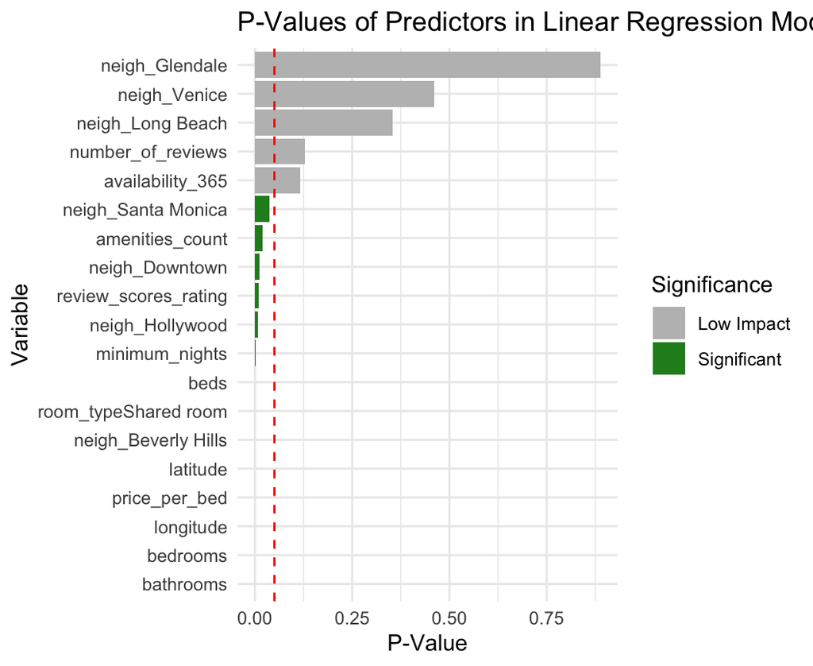

```r
# Load libraries
library(ggplot2)
library(dplyr)

# Create the dataset
pval_data <- data.frame(Variable = c("bedrooms", "bathrooms", "beds", "review_scores_rating",
    "minimum_nights", "latitude", "longitude", "room_typeShared room",
    "neigh_Beverly Hills", "neigh_Downtown", "neigh_Hollywood", "neigh_Santa Monica",
    "amenities_count", "price_per_bed", "neigh_Glendale", "neigh_Long Beach",
    "neigh_Venice", "number_of_reviews", "availability_365"), p_value = c(0.0000000000000002,
    0.0000000000000002, 0.0000016, 0.009727, 0.000635, 0.000000000000886,
    0.0000000000000002, 0.0000000123, 0.00000000589, 0.0112, 0.0083, 0.037,
    0.0195, 0.0000000000000002, 0.8881, 0.3544, 0.4613, 0.1274, 0.1156))

# Add a significance flag
pval_data <- pval_data %>%
    mutate(Significance = ifelse(p_value < 0.05, "Significant", "Low Impact"))

# Sort for better plotting
pval_data <- pval_data %>%
    arrange(p_value)

# Plot
ggplot(pval_data, aes(x = reorder(Variable, p_value), y = p_value, fill = Significance)) +
    geom_col() + coord_flip() + geom_hline(yintercept = 0.05, linetype = "dashed",
    color = "red") + labs(title = "P-Values of Predictors in Linear Regression Model",
    x = "Variable", y = "P-Value") + scale_fill_manual(values = c(Significant = "forestgreen",
    `Low Impact` = "gray")) + theme_minimal()
```

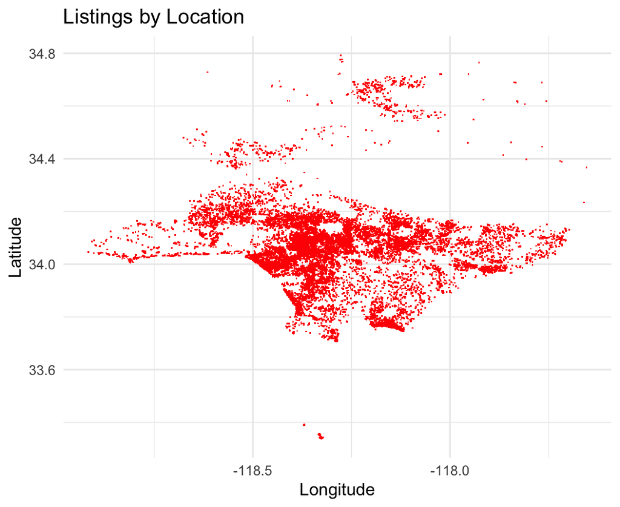

```r
# Map of rentals

ggplot(opt_LA_price, aes(x = longitude, y = latitude)) + geom_point(shape = ".",
    color = "red") + labs(title = "Listings by Location", x = "Longitude",
    y = "Latitude") + theme_minimal()
```

```r
# Split the data into training and testing sets

# Use rsample's initial_split() to create an 80/20 train/test split
set.seed(123)
opt_split <- initial_split(opt_LA_price, prop = 0.8)

# Extract training and testing sets
opt_LA_train <- training(opt_split)
opt_LA_test <- testing(opt_split)
```

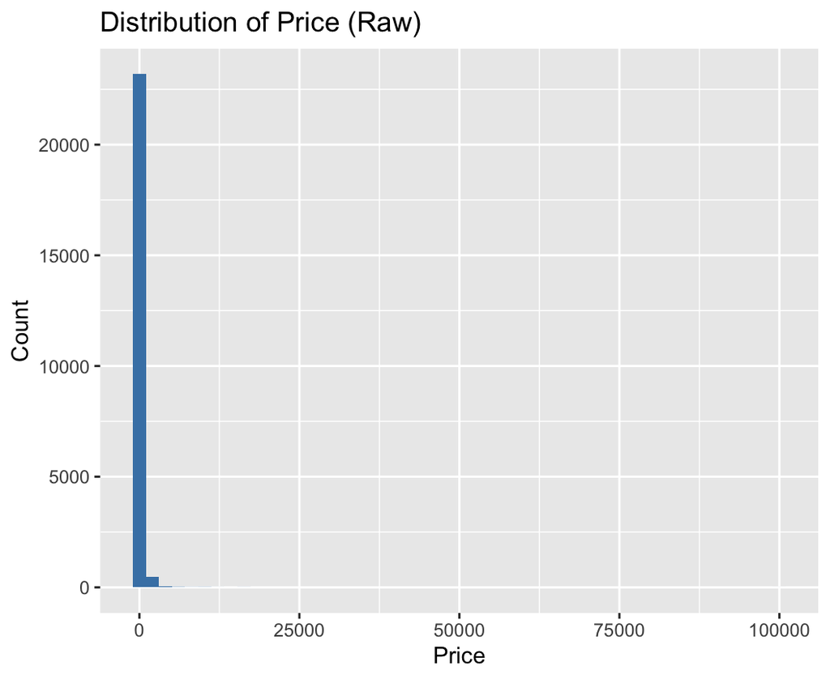

```r
# Price distribution (before and after log transform)
ggplot(opt_LA_price, aes(x = price)) + geom_histogram(bins = 50, fill = "steelblue") +
    labs(title = "Distribution of Price (Raw)", x = "Price", y = "Count")
```

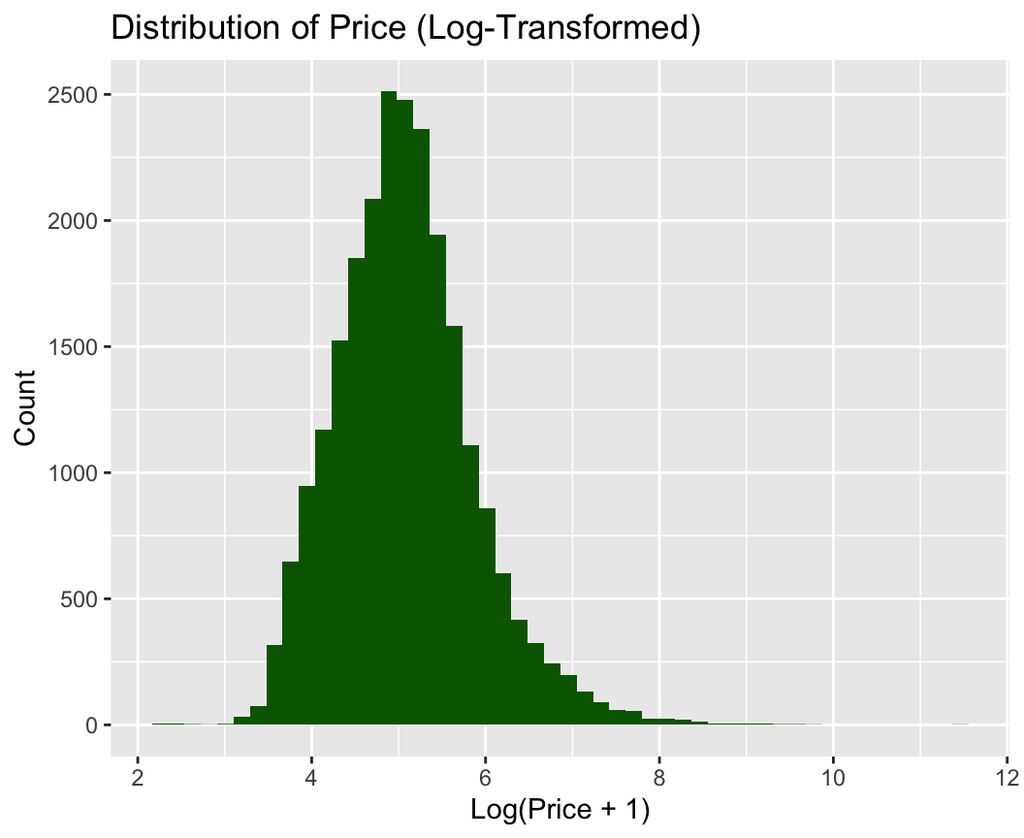

```r
ggplot(opt_LA_price, aes(x = log_price)) + geom_histogram(bins = 50, fill = "darkgreen") +
    labs(title = "Distribution of Price (Log-Transformed)", x = "Log(Price + 1)",
        y = "Count")
```

## 2.2 Model Building

### 2.2.1 Random Forest

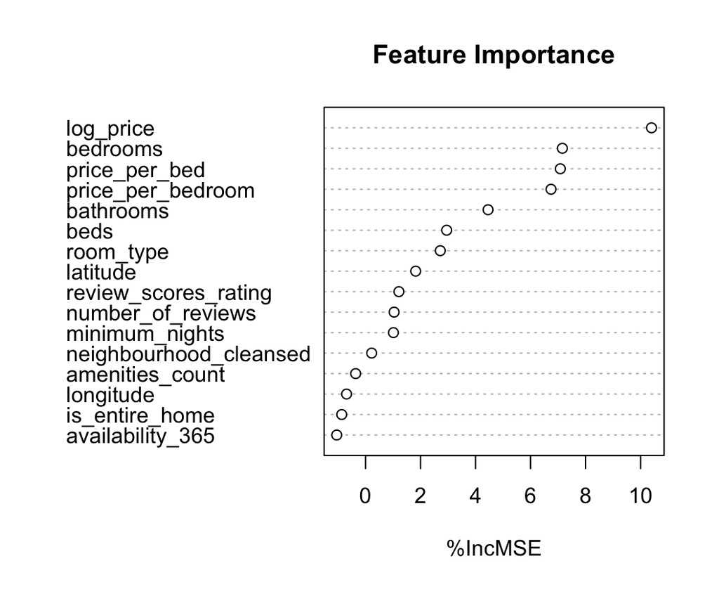

```r
# Train the Random Forest model

# Fit a random forrest regression model to predict nightly price
opt_rf_model <- randomForest(

  # Predict price using all other variables
  price ~ .,

  # Use training data only
  data = opt_LA_train,

  # Number of trees in the forest
  ntree = 100,

  # Track feature importance for interpretation
  importance = TRUE
)

# Feature importance from random forest
varImpPlot(opt_rf_model, type = 1, main = "Feature Importance")
```

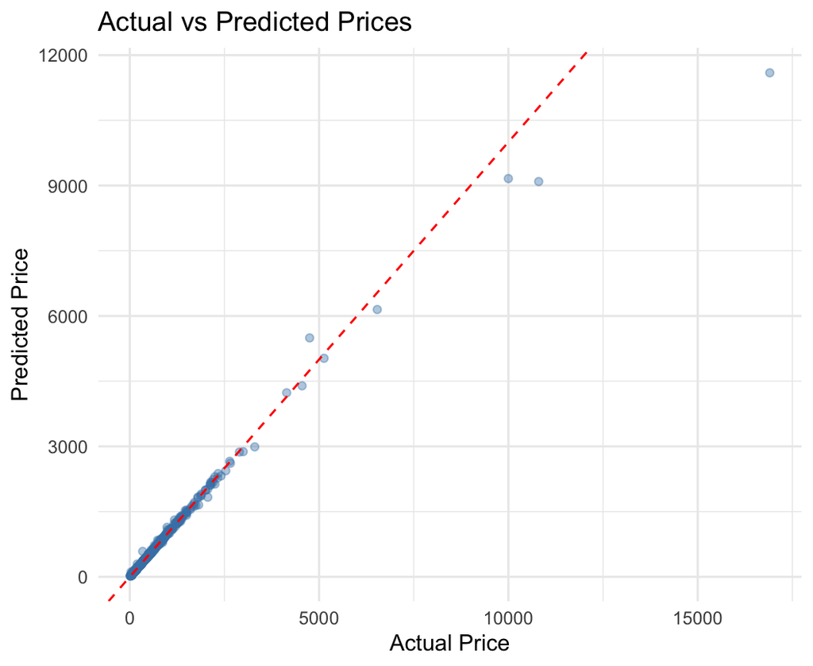

```r
# Predict on the test data
predictions <- predict(opt_rf_model, newdata = opt_LA_test)

# Calculate performance metrics
mae <- mean(abs(predictions - opt_LA_test$price))
rmse <- sqrt(mean((predictions - opt_LA_test$price)^2))
r2 <- cor(predictions, opt_LA_test$price)^2

# Print the results
cat("MAE:", round(mae, 2), "\n")
## MAE: 4.05
cat("RMSE:", round(rmse, 2), "\n")
## RMSE: 83.49
cat("R2:", round(r2, 3), "\n")
## R2: 0.975

# Actual vs Predicted price scatterplot
ggplot(data.frame(actual = opt_LA_test$price, predicted = predictions),
    aes(x = actual, y = predicted)) + geom_point(alpha = 0.4, color = "steelblue") +
    geom_abline(slope = 1, intercept = 0, color = "red", linetype = "dashed") +
    labs(title = "Actual vs Predicted Prices", x = "Actual Price", y = "Predicted Price") +
    theme_minimal()
```

## 2.3 Model Evaluation

MAE: 4.05 RMSE: 83.49 R2: 0.975

The R2 result is very high, and explains 97.5% of the variance seen in Airbnb prices. The MAE is relatively low and, like R2, suggests that the model performs well for most listings. The high RSME indicates that there are a few extreme-priced listings that produce large errors in the dataset. These listings may include luxury properties or otherwise unique offerings.

## 2.4 Price Optimization - Linear Regression Model

Since there are 3 objectives, all of which will require testing, training, and likely creation of similar data sets, all data groups created for linear regression price optimization will begin with “lm_”

```r
# Use the cleaned dataset from earlier steps Assuming opt_LA_price is
# already cleaned and preprocessed

# Step 1: Train/test split
set.seed(123)

lm_sample_index <- sample(nrow(opt_LA_price), 0.8 * nrow(opt_LA_price))
lm_opt_train <- opt_LA_price[lm_sample_index, ]
lm_opt_test <- opt_LA_price[-lm_sample_index, ]
```

```r
# Step 2: Fit a basic linear regression model
lm_model1 <- lm(price ~ room_type + neighbourhood_cleansed + number_of_reviews +
    review_scores_rating + minimum_nights + availability_365 + latitude +
    longitude + bedrooms + bathrooms + beds + amenities_count + price_per_bed +
    is_entire_home, data = lm_opt_train)
```

```r
# Step 3: Predict and evaluate

lm_preds <- predict(lm_model, newdata = lm_opt_test)
```

```r
# Step 4: Evaluate

actual <- lm_opt_test$price
mae <- mean(abs(actual - lm_preds))
rmse <- sqrt(mean((actual - lm_preds)^2))
r2 <- cor(actual, lm_preds)^2

cat("MAE:", round(mae, 2), "\n")
## MAE: 93.71
cat("RSME:", round(rmse, 2), "\n")
## RSME: 283.63
cat("R-squared:", round(r2, 3), "\n")
## R-squared: 0.59
```

# 3 Model Evaluation

MAE = $93.71. On average, our predicted prices are off by $93.71. This is a moderate error for price prediction.

RMSE = $283.63. There are some large prediction errors(possibly due to outliers or high-price listings). RMSE is more sensitive to these than MAE.

R-Squared = 0.59. The model explains 59% of the variation in listing prices. That means over half of the pricing behavior is captured by our input features, but 41% is unexplained. # Comparison to Random Forest Random Forest Results: MAE = $4.05 RMSE = $83.49 R-Squared = 0.975

Random Forest clearly outperforms linear regression in both accuracy and predictive power. Linear regression is easier to interpret, but sacrifices precision. The gap in RMSE suggests that linear regression struggles with more complex price dynamics - epsecially for high-end listings or where non-linear relationships exist.

# 4 Revenue Forecasting

Estimate annual revenue per listing using reported attributes of each listing for hosts to make informed decisions about setting prices and availability on their properties. Estimate expected future revenue for listings using pricing, availability, and booking history.

Since there are 3 objectives, all of which will require testing, training, and likely creation of similar data sets, all data groups created for revenue forecasting will begin with “rev_”.

## 4.1 Data Preparation

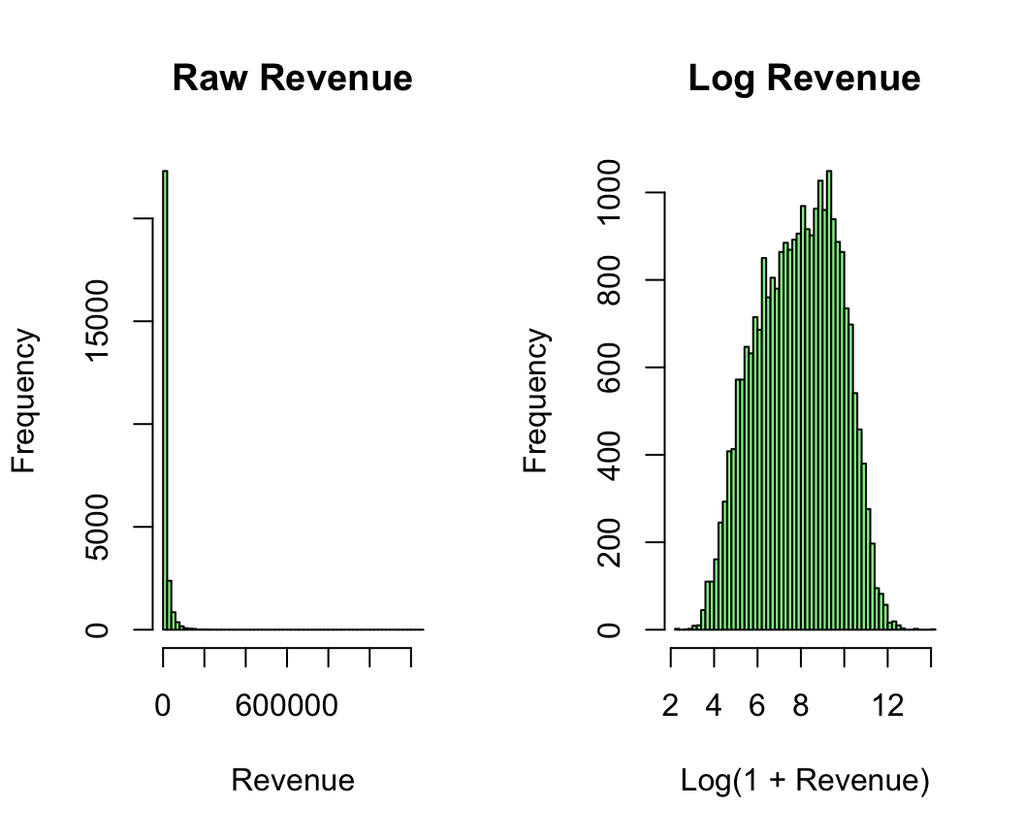

```r
# Select relevant columns and clean them for modeling

rev_LA_avail <- LA_listings %>%
  select(price, room_type, neighbourhood_cleansed, number_of_reviews, review_scores_rating,
         minimum_nights, availability_365, latitude, longitude, amenities,
         bedrooms, bathrooms, beds) %>%
  mutate(
    # Convert price string to numeric
    price = as.numeric(gsub("[$,]", "", price)),

    # Create proxy for bookings, allowing number of reviews to stand in for bookings if no booking data is available
    #This assumes a correlation between reviews and bookings, which likely underestimates revenue for newer listings
    proxy_bookings = number_of_reviews,

    # Create revenue variable and log-transformed revenue
    revenue = price * proxy_bookings,
    log_revenue = log1p(revenue),

    # Isolate availability by singular days
    availability_rate = availability_365 / 365,

    # Convert categorical variables to factors
    room_type = as.factor(room_type),
    neighbourhood_cleansed = as.factor(neighbourhood_cleansed),

    # Convert bedroom/bathroom/bed counts to numeric
    bedrooms = as.numeric(bedrooms),
    bathrooms = as.numeric(bathrooms),
    beds = as.numeric(beds),

    # Create a new numeric feature: count of amenities
    amenities_count = str_count(amenities, ",") + 1
  ) %>%
  select(-amenities) %>%  # Drop raw amenities text
  drop_na()

par(mfrow = c(1, 2))
hist(rev_LA_avail$revenue, main = "Raw Revenue", xlab = "Revenue", breaks = 50, col = "lightgreen")
hist(rev_LA_avail$log_revenue, main = "Log Revenue", xlab = "Log(1 + Revenue)", breaks = 50, col = "lightgreen")
```

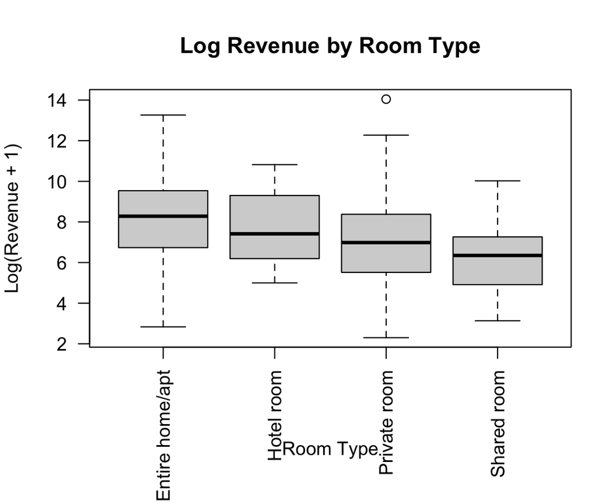

```r
# Create an 80/20 train/test split

rev_split <- initial_split(rev_LA_avail, prop = 0.8)

# Extract training and testing sets
rev_train <- training(rev_split)
rev_test <- testing(rev_split)

par(mar = c(7, 4, 4, 2))

# Boxplot
boxplot(log_revenue ~ room_type, data = rev_LA_avail, col = "lightgray",
    main = "Log Revenue by Room Type", xlab = "", ylab = "Log(Revenue + 1)",
    las = 2)

mtext("Room Type", side = 1, line = 4)
```

## 4.2 Data Engineering

```r
# We did not learn model.matrix in class, however, it was covered in
# BDS's section on regression and model selection in chapter 2

# Create revenue training and testing matrices
rev_train_matrix <- model.matrix(~. - 1, data = rev_train %>%
    select(-log_revenue))
rev_train_target <- rev_train$log_revenue

rev_test_matrix <- model.matrix(~. - 1, data = rev_test %>%
    select(-log_revenue))
rev_test_target <- rev_test$log_revenue
```

## 4.3 Forecasting Models

### 4.3.1 Elastic Net

```r
# Fit by using cross-validation across multiple alpha values
set.seed(123)

enet_mod <- cva.glmnet(x = rev_train_matrix, y = rev_train_target, alpha = seq(0,
    1, length = 11), family = "gaussian")

# Helper function to find the alpha with lowest cross-validation
# error
rev_get_alpha <- function(fit) {
    alpha <- fit$alpha
    error <- sapply(fit$modlist, function(mod) {
        min(mod$cvm)
    })
    alpha[which.min(error)]
}

# Helper function to extract alpha, lambda.min, lambda.1se, and error
rev_get_model_params <- function(fit) {
    alpha <- fit$alpha
    lambdaMin <- sapply(fit$modlist, `[[`, "lambda.min")
    lambdaSE <- sapply(fit$modlist, `[[`, "lambda.1se")
    error <- sapply(fit$modlist, function(mod) {
        min(mod$cvm)
    })
    best <- which.min(error)
    data.frame(alpha = alpha[best], lambdaMin = lambdaMin[best], lambdaSE = lambdaSE[best],
        error = error[best])
}

# Identify best alpha and lambda values
rev_best_alpha <- rev_get_alpha(enet_mod)
print(paste("Best alpha:", rev_best_alpha))
```

```
## [1] "Best alpha: 0.1"
```

```r
rev_model_params <- rev_get_model_params(enet_mod)
print(rev_model_params)
```

```
##   alpha  lambdaMin  lambdaSE    error
## 1   0.1 0.04584175 0.2446436 1.352027
```

```r
# Extract best model using optimal alpha
rev_best_model <- enet_mod$modlist[[which(enet_mod$alpha == rev_best_alpha)]]

# Predict log revenue using the best model and optimal lambda
rev_enet_predictions <- predict(rev_best_model, s = rev_model_params$lambdaMin,
    newx = rev_test_matrix)
```

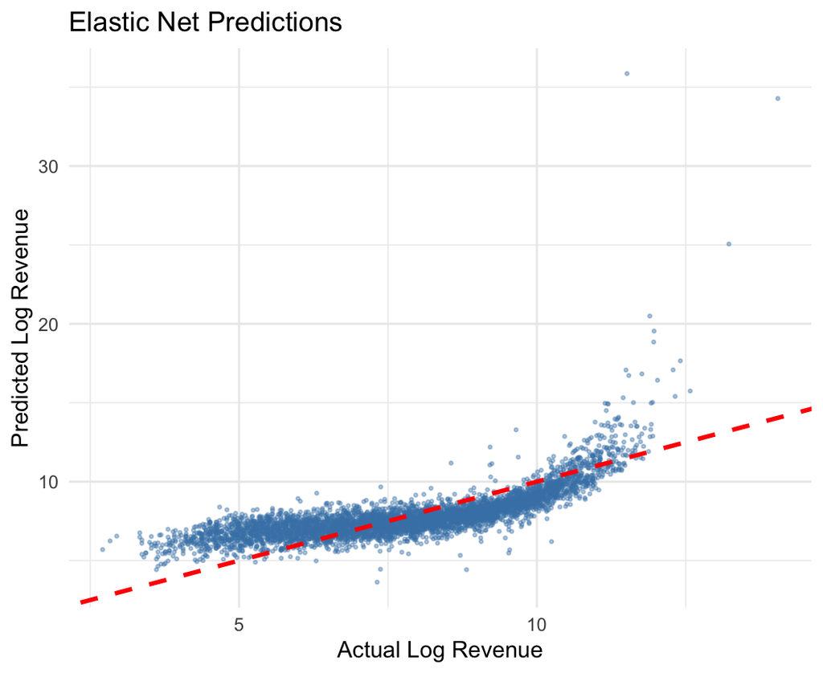

```r
# Evaluate model performance on the test set
rev_enet_mae <- mean(abs(rev_enet_predictions - rev_test_target))
rev_enet_rmse <- sqrt(mean((rev_enet_predictions - rev_test_target)^2))
rev_enet_r2 <- cor(rev_enet_predictions, rev_test_target)^2

# Output performance results
cat("Elastic Net (best alpha =", rev_best_alpha, ") - MAE:", round(rev_enet_mae,
    2), "\n")
## Elastic Net (best alpha = 0.1 ) - MAE: 0.94
cat("Elastic Net (best alpha =", rev_best_alpha, ") - RMSE:", round(rev_enet_rmse,
    2), "\n")
## Elastic Net (best alpha = 0.1 ) - RMSE: 1.24
cat("Elastic Net (best alpha =", rev_best_alpha, ") - R²:", round(rev_enet_r2,
    3), "\n")
## Elastic Net (best alpha = 0.1 ) - R²: 0.556

rev_plot_df <- data.frame(actual = as.numeric(rev_test_target), predicted = as.numeric(rev_enet_predictions))

ggplot(rev_plot_df, aes(x = actual, y = predicted)) + geom_point(color = "steelblue",
    alpha = 0.4, size = 0.5) + geom_abline(slope = 1, intercept = 0, color = "red",
    linetype = "dashed", size = 1) + labs(title = "Elastic Net Predictions",
    x = "Actual Log Revenue", y = "Predicted Log Revenue") + theme_minimal()
```

## 4.4 Model Evaluation

Since we are unable to see actual revenue per listing, it can be assumed that revenue is highly skewed based on seasonality and dynamic pricing.

End: Revenue forecasting

# 5 Market Segmentation

## 5.1 General Segmentation

The following lines are the first round of market segmenting through clustering models with “general” signifiers. These are taken as simple features that are standard across Airbnbs.

### 5.1.1 Data Preperation

```r
# Select relevant columns and clean them for modeling, including both features of the property and indications of demand.
mktseg_cluster_data_general <- LA_listings %>%
  select(price, bedrooms, bathrooms, beds, review_scores_rating, availability_365, amenities) %>%
  mutate(

    # Convert price to numeric by removing formatting
    price = as.numeric(gsub("[$,]", "", price)),

    bedrooms = as.numeric(bedrooms),
    bathrooms = as.numeric(bathrooms),
    beds = as.numeric(beds),
    review_scores_rating = as.numeric(review_scores_rating),
    availability_365 = as.numeric(availability_365),
    amenities_count = str_count(amenities, ",") + 1
  ) %>%

  #Now that amenities are counted, we drop the actual amenities inputs
  select(-amenities) %>%
  drop_na() %>%

#Sampling ~10% of data set

slice(1:4500)

#Scale variables so that they contribute equally, even when initially measured by different units (price v. rating)
mktseg_cluster_data_scaled_general <- scale(mktseg_cluster_data_general)
```

### 5.1.2 Modeling

#### 5.1.2.1 K-means

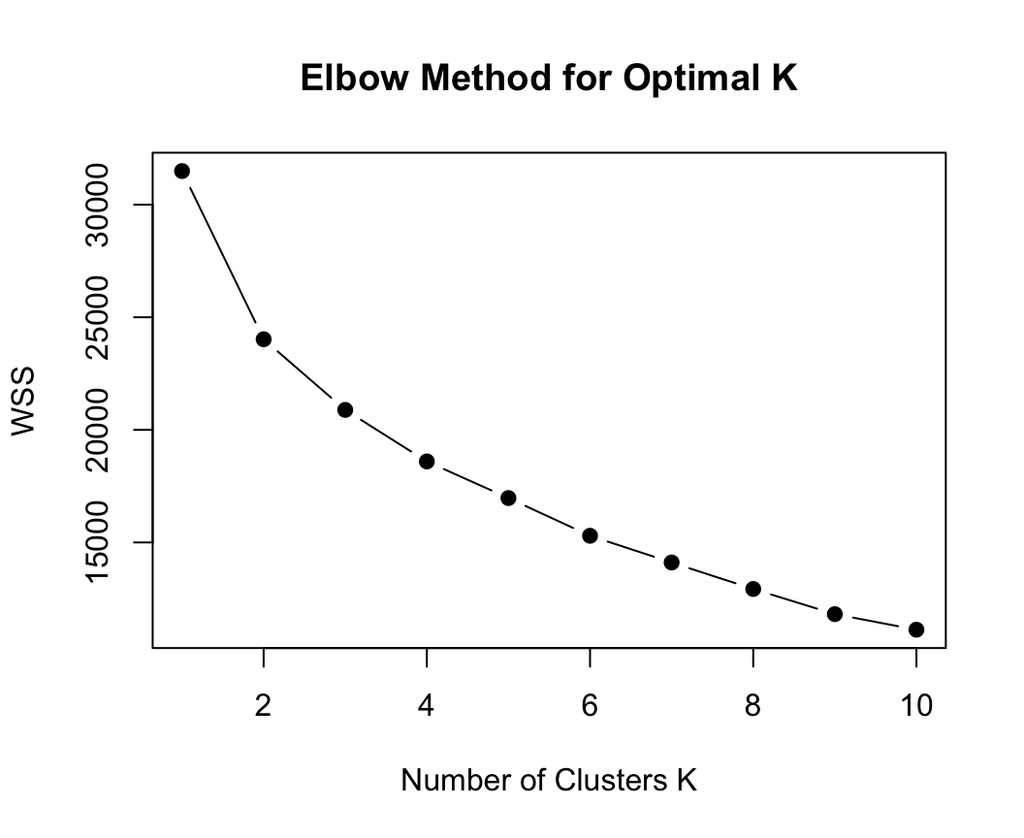

```r
# Elbow Method to Choose Optimal K

wss <- function(k) {
    kmeans(mktseg_cluster_data_scaled_general, centers = k, nstart = 25)$tot.withinss
}
wss_values <- map_dbl(1:10, wss)

plot(1:10, wss_values, type = "b", pch = 19, xlab = "Number of Clusters K",
    ylab = "WSS", main = "Elbow Method for Optimal K")
```

#### 5.1.2.2 PCA

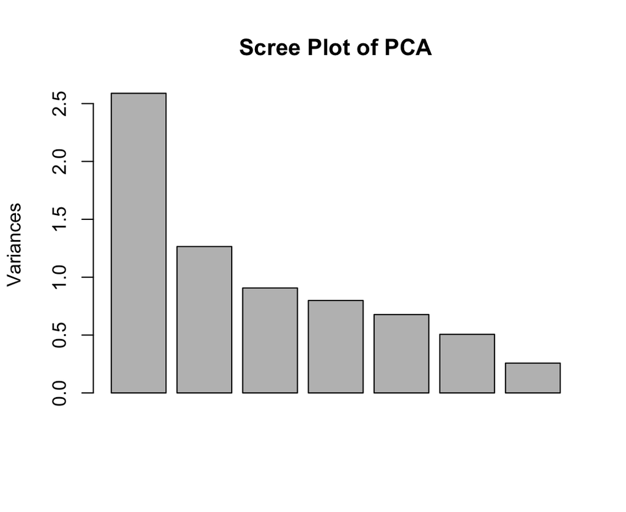

```r
# Run PCA on the scaled general data
mktseg_pca_general <- prcomp(mktseg_cluster_data_scaled_general, scale = FALSE)

# Perform K-means clustering on scaled general data
kmeans_general_result <- kmeans(mktseg_cluster_data_scaled_general, centers = 8,
    nstart = 25)

# Add cluster labels to original unscaled general data
mktseg_clustered_general <- mktseg_cluster_data_general %>%
    mutate(segment = as.factor(kmeans_general_result$cluster))

# Scree plot of PCA
screeplot(mktseg_pca_general, main = "Scree Plot of PCA")
```

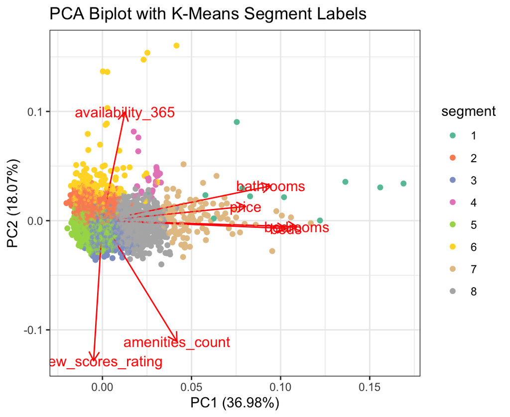

```r
# PCA biplot with cluster segments
autoplot(mktseg_pca_general, data = mktseg_clustered_general, colour = "segment",
    loadings = TRUE, loadings.label = TRUE, loadings.label.size = 4) +
    geom_point(aes(color = segment), alpha = 0.4, size = 0.5) + scale_color_brewer(palette = "Set2") +
    theme_bw() + ggtitle("PCA Biplot with K-Means Segment Labels")
```

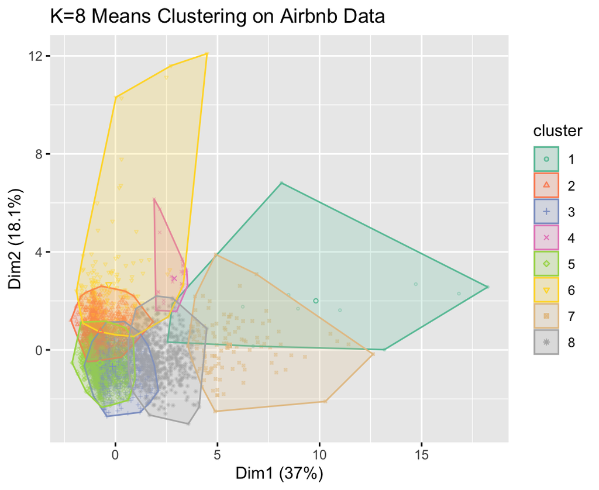

```r
# Add the resulting cluster assignments as a new variable,so now each
# row belongs to one of the k (8) market segments (labeled as 1
# through 8)

fviz_cluster(kmeans_general_result, data = mktseg_cluster_data_scaled_general,
    main = "K=8 Means Clustering on Airbnb Data", palette = "Set2", geom = "point",
    pointsize = 0.5, alpha = 0.4, show.clust.cent = TRUE, repel = TRUE)
```

```r
# Track row IDs for consistent matching with clustering results
mktseg_clustered_general <- mktseg_cluster_data_general %>%
    mutate(segment = as.factor(kmeans_general_result$cluster))

# Summarize the characteristics of each segment, helps interpret how
# different segments differ in key features (e.g., price, size,
# amenities)
mktseg_segment_summary_general <- mktseg_clustered_general %>%
    group_by(segment) %>%
    summarise(avg_price = mean(price), avg_bedrooms = mean(bedrooms), avg_bathrooms = mean(bathrooms),
        avg_beds = mean(beds), avg_rating = mean(review_scores_rating,
            na.rm = TRUE), avg_amenities = mean(amenities_count), avg_availability = mean(availability_365))

# View the summary table of cluster profiles
print(mktseg_segment_summary_general)
```

```
## # A tibble: 8 × 8
##   segment avg_price avg_bedrooms avg_bathrooms avg_beds avg_rating
##   <fct>       <dbl>        <dbl>         <dbl>    <dbl>      <dbl>
## 1 1          7387.         4.58           5.46     4.83       4.60
## 2 2           134.         1.04           1.14     1.40       4.81
## 3 3           173.         1.24           1.17     1.74       4.88
## 4 4            46.2        0.906          9.53     1.88       4.51
## 5 5           136.         1.05           1.12     1.43       4.85
## 6 6           200.         1.30           1.31     1.80       4.06
## 7 7          1274.         4.80           4.51     7.24       4.82
## 8 8           427.         3.13           2.31     3.99       4.84
## # ℹ 2 more variables: avg_amenities <dbl>, avg_availability <dbl>
```

```
##   cluster size ave.sil.width
## 1       1   12          0.16
## 2       2 1254          0.30
## 3       3  867          0.19
## 4       4   32          0.64
## 5       5 1416          0.27
## 6       6  162          0.03
## 7       7  118          0.03
## 8       8  639          0.14
```

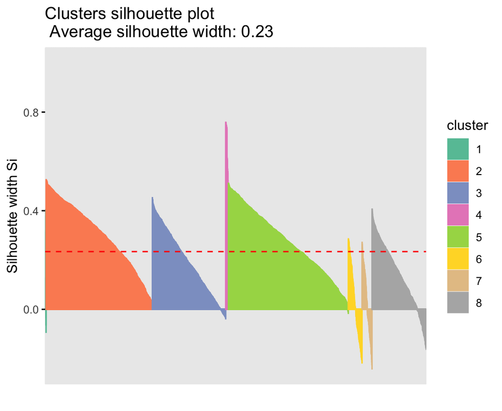

```r
# Compute silhouette scores
silhouette_score_general <- silhouette(kmeans_general_result$cluster, dist(mktseg_cluster_data_scaled_general))

# Visualize silhouette plot
fviz_silhouette(silhouette_score_general, palette = "Set2", ggtheme = theme_minimal(),
    print.summary = TRUE)
```

Understanding silhouette scores: ~0.5+ = strong structure ~0.25–0.5 = fair structure ~0.0–0.25 = weak structure, potentially overlapping clusters < 0 = potential misclassification